# AD1 - Dados sobre séries de TV

Arthur Vinícius Tomé Rodrigues

April 26, 2018

Para a realização dessa análise, utilizaremos os dados das seguintes séries: *The Walking Dead*, *Archer* e *The Office*.

```r
dados = read_csv(here("data/series_from_imdb.csv"),
                    progress = FALSE,
                    col_types = cols(.default = col_double(),
                                     series_name = col_character(),
                                     episode = col_character(),
                                     url = col_character(),
                                     season = col_character()))

dados = dados %>% filter(series_name %in% c("The Walking Dead", "Archer", "The Office"))
```

## Série mais bem avaliada?

Desejamos saber qual das séries escolhidas é a mais bem avaliada no IMDB.

Temos, para cada série, a nota dada pelos usuários em cada episódio. Vamos definir a **média** dessas notas (para a série como um todo) como método de comparação entre as séries.

```r
dados %>%
    group_by(series_name) %>%
    summarise(media = mean(user_rating))
```

| series_name | media |
| --- | --- |
| Archer | 8.090426 |
| The Office | 8.267021 |
| The Walking Dead | 8.322222 |

Podemos ver que a série mais bem avaliada foi *The Walking Dead*, com uma média de ~8.32.

No entanto, a diferença entre a avaliação geral das séries é bem pequena, tendo *Archer* (a pior avaliada) apenas 0.23 pontos a menos em sua média.

### E em relação a cada temporada?

Até agora só avaliamos as séries como um todo, mas sempre há episódios/temporadas que se destacam entre os outros, que marcam os fãs das séries.

Então, analisando mais profundamente, será que esse ranking se mantém ao longo das temporadas?

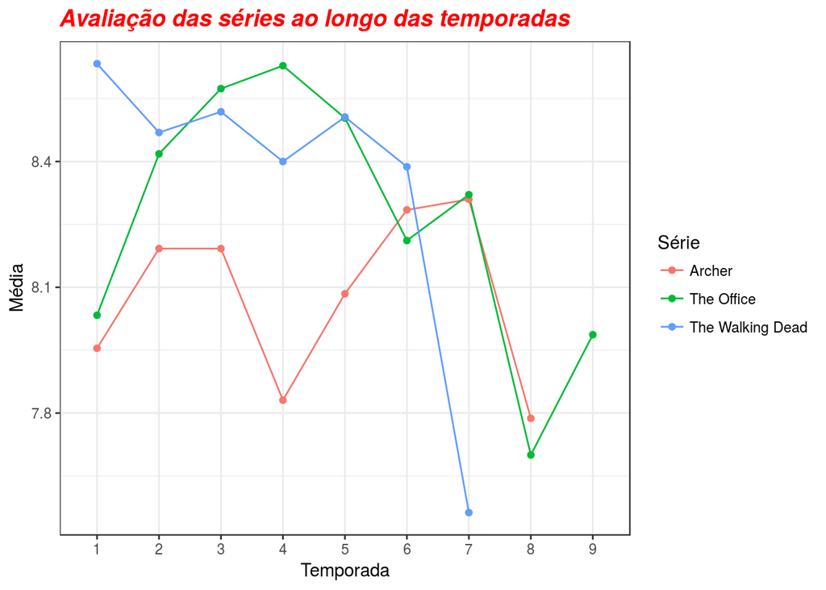

```r
avaliacao_temporadas = dados %>%
                       group_by(series_name, season) %>%
                       summarise(media = mean(user_rating))

avaliacao_temporadas %>%
    ggplot(aes(x = season, y = media, color = series_name)) +
    ggtitle("Avaliação das séries ao longo das temporadas") +
    theme(plot.title = element_text(color="red", size=14, face="bold.italic")) +
    geom_line(aes(colour=series_name, group=series_name)) +
    geom_point() +
    labs(x = "Temporada", y = "Média", color = "Série")
```

É fácil perceber a grande variação da avaliação das séries ao decorrer das temporadas.

Nas duas primeiras temporadas, a avaliação está de acordo com o que havíamos calculado antes (Melhor: The Walking Dead, Médio: The Office, Pior: Archer). Porém, a partir da terceira temporada, o cenário começa a mudar.

Dados interessantes:

```
- Há uma grande queda da avaliação de The Walking Dead em sua última temporada.
- The Office também apresenta uma grande queda a partir da quinta temporada.
- Archer possui a avaliação com menor variação no decorrer das temporadas.
```

## Irregularidade na qualidade dos episódios

Será que a avaliação das séries varia muito ao decorrer dos episódios? Vamos analisar isso para cada série separadamente.

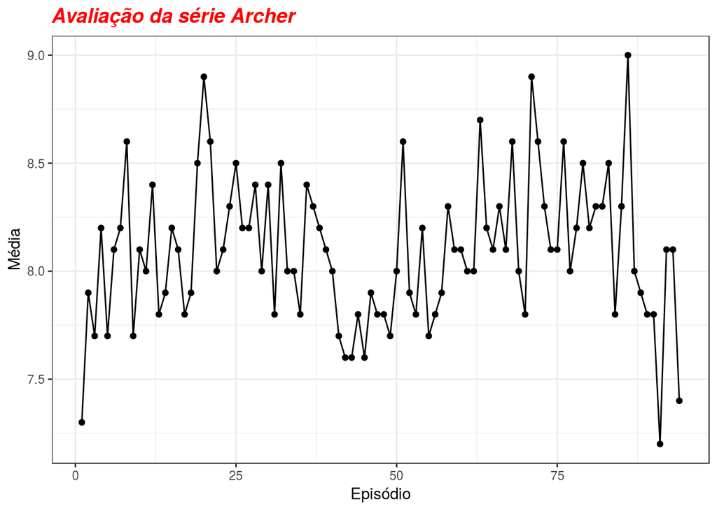

```r
av_archer = dados %>%
                       filter(series_name == "Archer") %>%
                       group_by(series_name, series_ep) %>%
                       summarise(media = mean(user_rating))

av_archer %>%
    ggplot(aes(x = series_ep, y = media)) +
    ggtitle("Avaliação da série Archer") +
    theme(plot.title = element_text(color="red", size=14, face="bold.italic")) +
    geom_line() +
    geom_point() +
    labs(x = "Episódio", y = "Média")
```

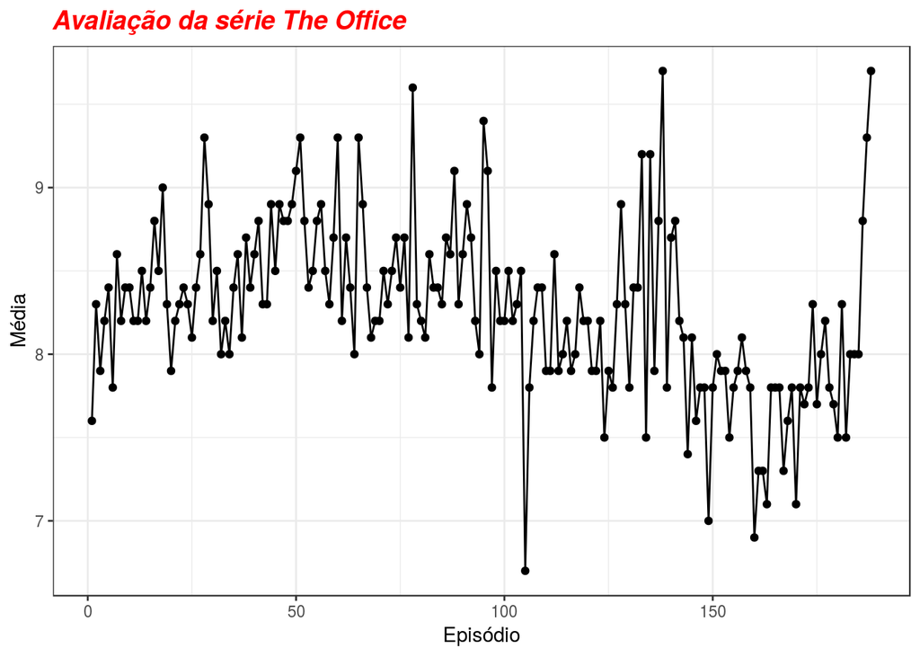

```r
av_the_office = dados %>%
                       filter(series_name == "The Office") %>%
                       group_by(series_name, series_ep) %>%
                       summarise(media = mean(user_rating))

av_the_office %>%
    ggplot(aes(x = series_ep, y = media)) +
    ggtitle("Avaliação da série The Office") +
    theme(plot.title = element_text(color="red", size=14, face="bold.italic")) +
    geom_line() +
    geom_point() +
    labs(x = "Episódio", y = "Média")
```

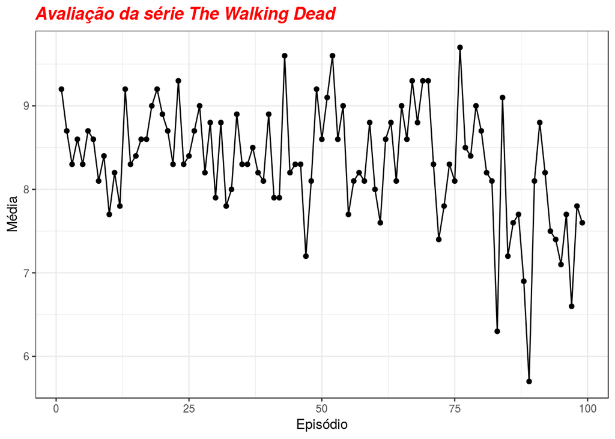

```r
av_the_walking_dead = dados %>%
                       filter(series_name == "The Walking Dead") %>%
                       group_by(series_name, series_ep) %>%
                       summarise(media = mean(user_rating))

av_the_walking_dead %>%
    ggplot(aes(x = series_ep, y = media)) +
    ggtitle("Avaliação da série The Walking Dead") +
    theme(plot.title = element_text(color="red", size=14, face="bold.italic")) +
    geom_line() +
    geom_point() +
    labs(x = "Episódio", y = "Média")
```

Podemos facilmente concluir que a avaliação das 3 séries possui uma recorrente variação ao decorrer dos episódios, sendo *The Walking Dead* a que apresenta maior variação/irregularidade, tendo como nota máxima quase 10, e nota mínima abaixo de 6.